# path analysis workshop

Alfons Edmar

2022-04-26

These are the main packages we will be using. Note that you need OpenMX to use the semPlot package, but that is often installed together with semPlot.

```r
#if you never used these packages before, you need to install them first before loading them in to r with the library function

#install.packages(tidyverse)
#install.packages(lavaan)
#install.packages(semPlot)
#install.packages(MVN)

library(tidyverse)
library(lavaan)
library(semPlot)
library(MVN)
```

The data we´ll be using is the path analysis data available on canvas here: https://canvas.gu.se/courses/54194/files/5947391?module_item_id=644814 Let´s load the data - we need the packages haven for this since it´s an spss file

```r
library(haven)
data <- read_sav("data path analysis spring 22.sav")
#note. this is my path to the data and to access the file you need to import it yourself
```

Let´s take a peek at what we are working with.

```r
summary(data)
```

```
##      stress       satisfaction   turnover_intent    demands
##  Min.   :0.600   Min.   :0.000   Min.   :0.000   Min.   :1.000
##  1st Qu.:1.500   1st Qu.:2.000   1st Qu.:1.000   1st Qu.:2.000
##  Median :2.000   Median :2.000   Median :1.500   Median :2.000
##  Mean   :1.993   Mean   :2.578   Mean   :1.896   Mean   :2.363
##  3rd Qu.:2.333   3rd Qu.:3.000   3rd Qu.:3.000   3rd Qu.:3.000
##  Max.   :5.000   Max.   :5.000   Max.   :5.000   Max.   :5.000
##     support
##  Min.   :1.000
##  1st Qu.:2.333
##  Median :2.667
##  Mean   :2.732
##  3rd Qu.:3.000
##  Max.   :5.000
```

All variables are numeric and and seems to range between 0 and 5. Note that some variables are ordinal, that is, they are whole numbers that are not continous, that is, the distance between 1 and 2 cannot be assumed to be the same as between 3 and 4. If we want to assume this, the data needs to normally distributed. So let´s take a look at the distributions. Note however that this is NOT the normality assumtion of the linear regression but rather an assumtion of using ordinal data as if they were continouos.

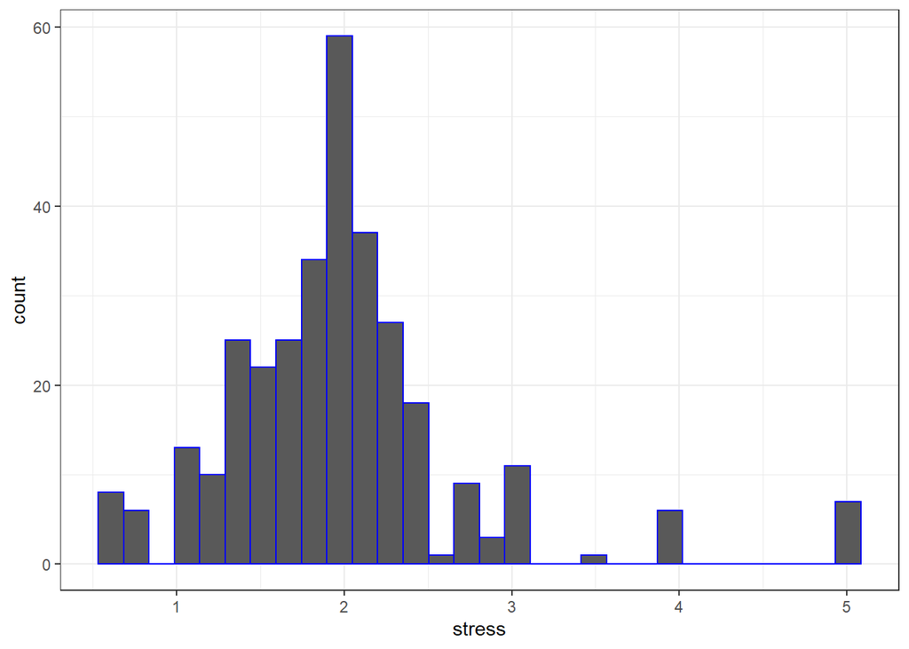

```r
ggplot(data, aes(stress))+
  geom_histogram(colour = 'blue')+
  theme_bw()
```

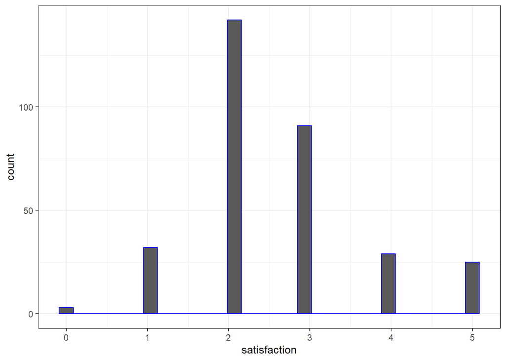

```r
#it has a normal look, and it seems to be continous measure, this is good.

ggplot(data, aes(satisfaction))+
  geom_histogram(colour = 'blue')+
  theme_bw()
```

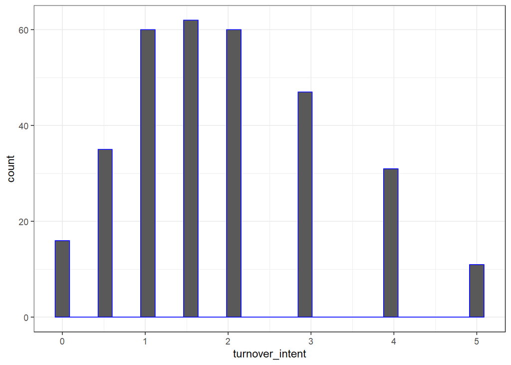

```r
#again, quite normal looking - this is ordinal but could be treated as if continous with some mental gymnastics

ggplot(data, aes(turnover_intent))+
  geom_histogram(colour = 'blue')+
  theme_bw()
```

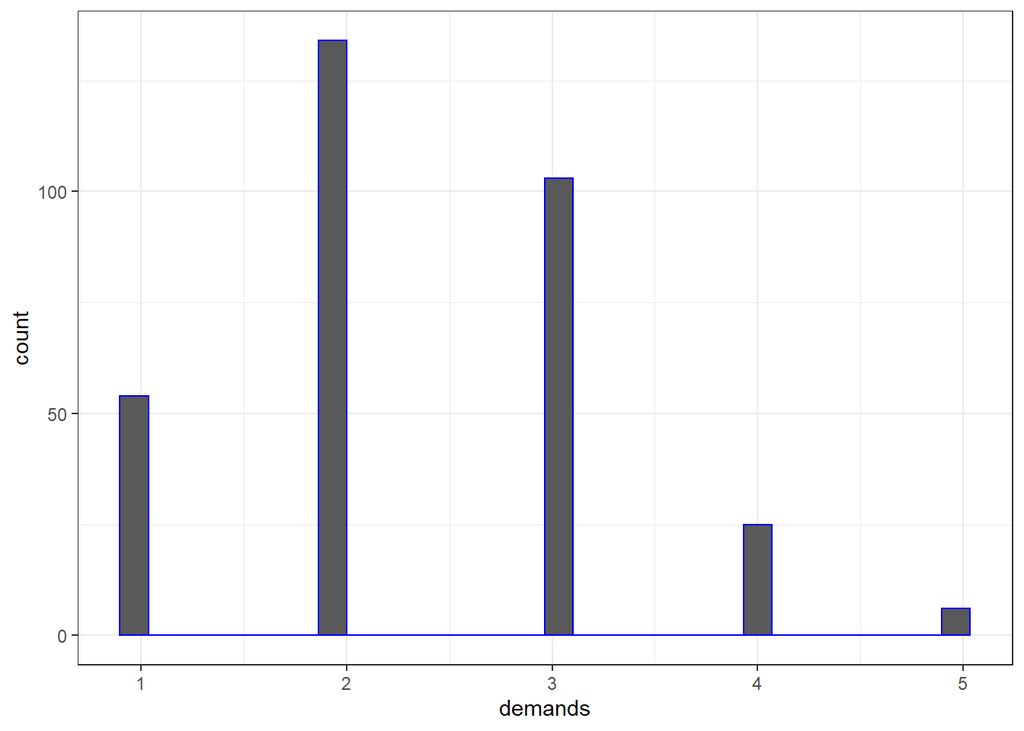

```r
#interesting, perhaps its measured in half steps? but that begs the question why none of the higher valus such as 4.5 exists, it seems to stop after 2. Strange.

ggplot(data, aes(demands))+
  geom_histogram(colour = 'blue')+
  theme_bw()
```

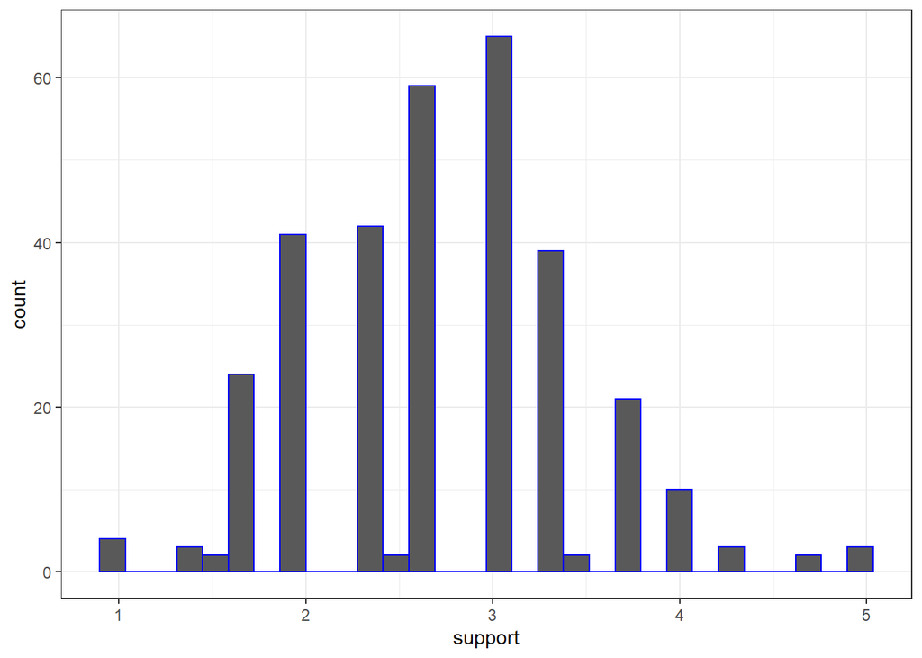

```r
#like satisfaction, looks pretty good.

ggplot(data, aes(support))+
  geom_histogram(colour = 'blue')+
  theme_bw()
```

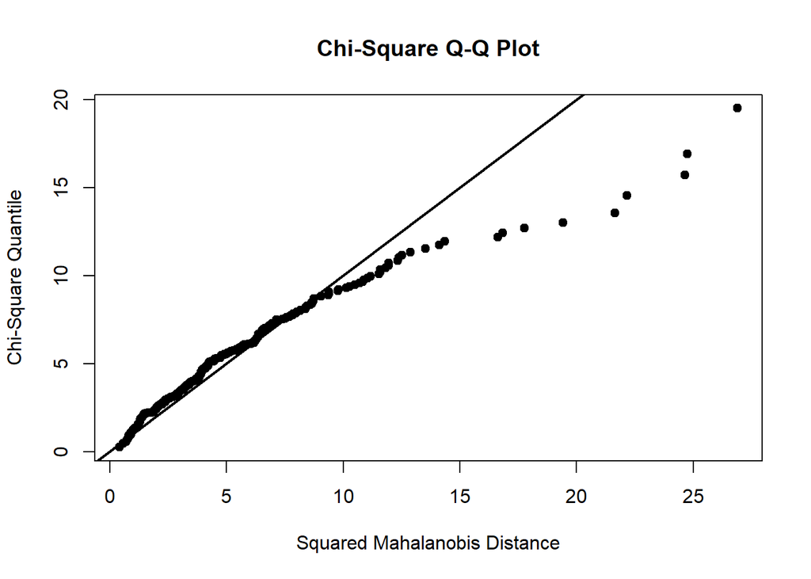

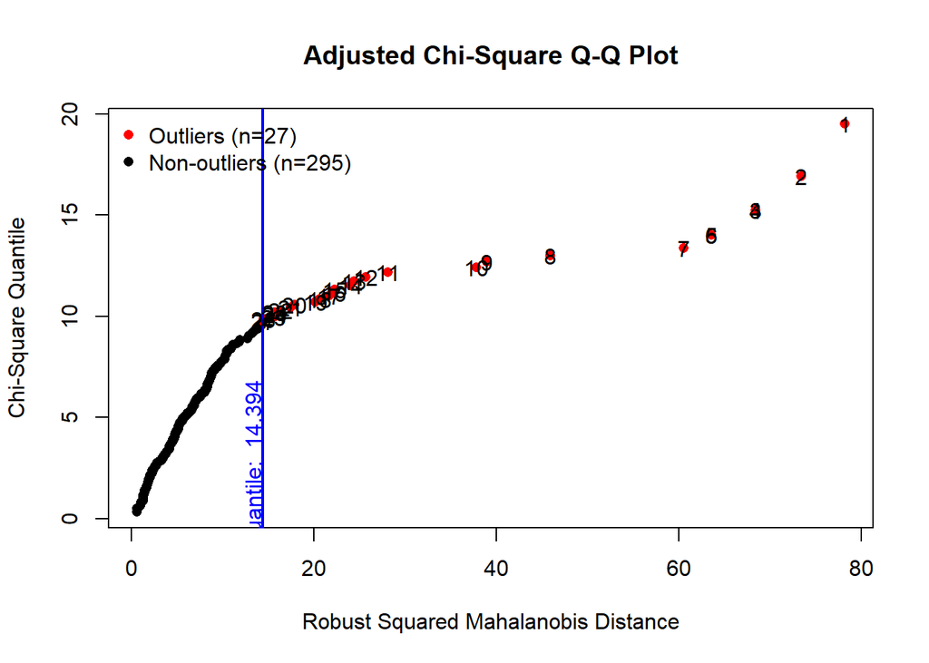

```r
#now this is a strange looking distribution...it looks to be a continuous measure and the density of the curve should be quite normal.

#However, we need to check the normality of our predicted variables when we have them. Before that we can check the normality tests. One common measure is mardia, so let´s use that. We can also look at some of the qq-plots and the outlier measures. Let´s save the scores in a list called normality_diagnostics

normality_diagnostics <- mvn(data
    , mvnTest = 'mardia' #takes maridas test
    , multivariatePlot = 'qq' #normal chi2 qq-plot
    , univariateTest = 'AD' #anderson-darling test for univariat normality
    , showOutliers = TRUE
    , showNewData = TRUE #stores a tibble without the outliers
    , multivariateOutlierMethod = 'adj') #takes the adjusted mahalanobis distance
```

```r
normality_diagnostics$Descriptives
```

```
##                   n     Mean   Std.Dev   Median Min Max     25th   75th
## stress          322 1.992847 0.7447653 2.000000 0.6   5 1.500000 2.3325
## satisfaction    322 2.577640 1.0715218 2.000000 0.0   5 2.000000 3.0000
## turnover_intent 322 1.895963 1.2288900 1.500000 0.0   5 1.000000 3.0000
## demands         322 2.363354 0.9145545 2.000000 1.0   5 2.000000 3.0000
## support         322 2.731884 0.7106893 2.666667 1.0   5 2.333333 3.0000
##                      Skew     Kurtosis
## stress          1.5307216  4.593582827
## satisfaction    0.6089998  0.130539733
## turnover_intent 0.7192168 -0.169774465
## demands         0.4177021 -0.002784417
## support         0.2551844  0.298869065
```

```r
normality_diagnostics$univariateNormality
```

```
##               Test        Variable Statistic   p value Normality
## 1 Anderson-Darling     stress         8.7723  <0.001      NO
## 2 Anderson-Darling  satisfaction     17.5045  <0.001      NO
## 3 Anderson-Darling turnover_intent    9.3350  <0.001      NO
## 4 Anderson-Darling     demands       16.5444  <0.001      NO
## 5 Anderson-Darling     support        3.2055  <0.001      NO
```

```r
normality_diagnostics$multivariateNormality
```

```
##              Test        Statistic              p value Result
## 1 Mardia Skewness 460.776024749078 1.05636187815355e-75     NO
## 2 Mardia Kurtosis 8.96312473441598                    0     NO
## 3             MVN             <NA>                 <NA>     NO
```

So, nothing is normal and we have quite a few outliers according to Mahalanobis. If we want an outlier free data set the mvn function saves it for us. Let´s try to extract the clean data from the normality diagnostics.

```r
clean_data <- normality_diagnostics$newData
```

Here we have the data without the 27 outliers indicated by the normality diagnostics. I´m not a fan of this type of diagnotics, but we can use the raw data as a type of sensativity analysis later on, for now lets move on using the clean data.

Since we don´t really know what we are doing it´s always good to look at the correlations to inform us about what connections lie within our sample. So let´s do that and then try to find a good model for our data.

```r
#this gives a normal correlation matrix
cor(clean_data)
```

```
##                      stress satisfaction turnover_intent     demands    support
## stress           1.00000000   -0.4892677      0.22641261 -0.04095583 -0.3617246
## satisfaction    -0.48926773    1.0000000     -0.59110506  0.12206989  0.3145087
## turnover_intent  0.22641261   -0.5911051      1.00000000  0.03633829 -0.2111387
## demands         -0.04095583    0.1220699      0.03633829  1.00000000  0.1464965
## support         -0.36172462    0.3145087     -0.21113872  0.14649650  1.0000000
```

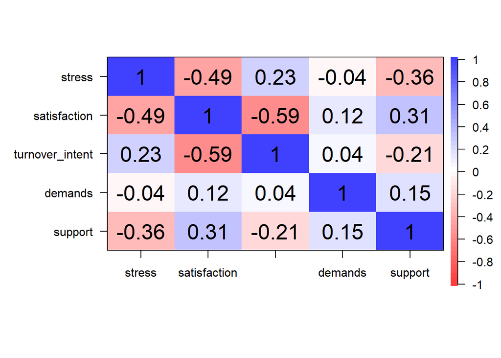

```r
#we can however plot the data out using the corplot from the psych package like so:
psych::corPlot(cor(clean_data))
```

```r
#note. the omitted variable in the bottom is turnover_intent
```

Stress,support and satisfaction seems to be correlated just fine. Demands seem to be a quite superflous variable having low correlations to all other variables. So let´s build a model where stress and support are allowed to correlate and that both have a causal inpact on the satisfaction you have in the workplace. Let´s also say that support and satisfactoin has a causal inpact on your turnover intent. Let´s contruct this model using the lavaan syntax.

```r
model.1 <- ('
             #regressions
             satisfaction    ~ stress + support
             turnover_intent ~ satisfaction
             turnover_intent ~ support

             #covariates
             stress ~~ support
            ')
#note. Lavaan syntax can be quite complicated. Lucky us we have the sem function that can handle very simple communication. In lavaan, we specify relationships with tilde(~), double tilde(~~) and equalmarks tilde(=~), where the single tilde represents a regression, a double tilde a correlation and an equals tilde a latent variable(which we will note use in path analysis)
```

Now that we have our model - specified in text - we can fit that model using lavaans sem function.

```r
fit.1 <- sem(  model = model.1   #the model we want to fit
             , data = clean_data #the data we want to fit the model on
             , estimator = 'MLM' #the estimator we use(robust maximum liklihood)
)
```

Now that we have our fit we can summarise the results

```r
summary(fit.1                  #the fit we want to summarize
        , standardize  = TRUE  #we want the standarized estimates
        , fit.measures = TRUE  #we also want the fit measures(CFI, TLI)
        , rsquare      = TRUE  #if we want to r2 for the model
)
```

```
## lavaan 0.6-9 ended normally after 18 iterations
##
##   Estimator                                         ML
##   Optimization method                           NLMINB
##   Number of model parameters                         9
##
##   Number of observations                           295
##
## Model Test User Model:
##                                               Standard      Robust
##   Test Statistic                                 3.014       2.867
##   Degrees of freedom                                 1           1
##   P-value (Chi-square)                           0.083       0.090
##   Scaling correction factor                                  1.051
##        Satorra-Bentler correction
##
## Model Test Baseline Model:
##
##   Test statistic                               260.797     208.698
##   Degrees of freedom                                 6           6
##   P-value                                        0.000       0.000
##   Scaling correction factor                                  1.250
##
## User Model versus Baseline Model:
##
##   Comparative Fit Index (CFI)                    0.992       0.991
##   Tucker-Lewis Index (TLI)                       0.953       0.945
##
##   Robust Comparative Fit Index (CFI)                         0.992
##   Robust Tucker-Lewis Index (TLI)                            0.954
##
## Loglikelihood and Information Criteria:
##
##   Loglikelihood user model (H0)              -1420.264   -1420.264
##   Loglikelihood unrestricted model (H1)      -1418.757   -1418.757
##
##   Akaike (AIC)                                2858.528    2858.528
##   Bayesian (BIC)                              2891.711    2891.711
##   Sample-size adjusted Bayesian (BIC)         2863.169    2863.169
##
```

[output cut: 31 more lines]

```
##                    Estimate  Std.Err  z-value  P(>|z|)   Std.lv  Std.all
##   stress ~~
##     support          -0.178    0.044   -4.093    0.000   -0.178   -0.362
##
## Variances:
##                    Estimate  Std.Err  z-value  P(>|z|)   Std.lv  Std.all
##    .satisfaction      0.850    0.066   12.878    0.000    0.850    0.739
##    .turnover_intnt    0.994    0.074   13.440    0.000    0.994    0.650
##     stress            0.536    0.081    6.649    0.000    0.536    1.000
##     support           0.454    0.043   10.580    0.000    0.454    1.000
##
## R-Square:
##                    Estimate
##     satisfaction      0.261
##     turnover_intnt    0.350
```

So our model fits remarkably well. Not even the chi2 is signifcant. Also not how much better our model is than the baseline model. One bad thing is the fact that we are not very couragous, we only have one degree of freedom. Let´s plot this model out using semPlot and then try improve our fit even more.

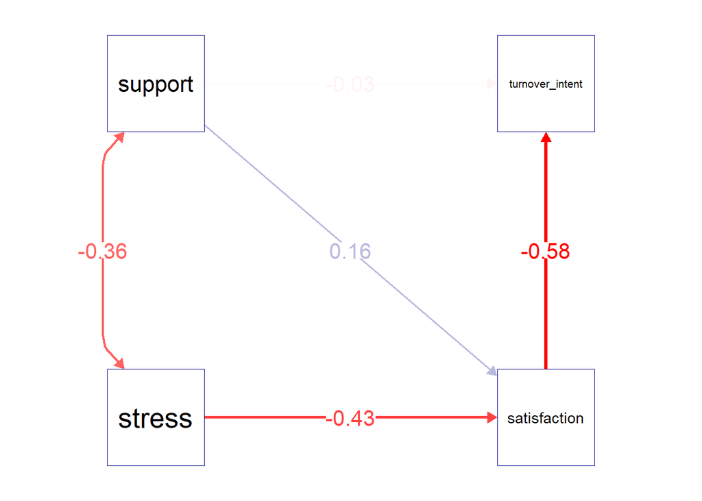

```r
semPaths( object = fit.1       #the fit we want to plot(our model)
         , what  = 'est, std'  #what we want to plot(the z-coefficients)
         , style = 'lisrel'    #the style of the plot
         , curvePivot = TRUE   #manipulates how the lines look
         , esize = 4           #the size of our lines
         , nCharNodes = 0      #takes all the characters in our manifest vars
         , edge.label.cex = 1.5#how big the estimates are(indicated in "what =")
         , residuals = FALSE   #removes the residual loops
         , sizeMan = 15         #indicates the width of manifest variables
         , rotation = 2        #how we want to rotate the plot(wich direction)
         , theme = 'Borkulo')  #the theme we want to use, i like this one
```

```r
#looks pretty good right? but notice the very weak trace between support and turnover intent and satisfaction!
```

Let´s interprate this. We can see that the correlation between support and stress is -.36 (as we saw in the correlation plot). We can also see that for every unit increase in stress satisfaction decreased with .43 standard deviations. We also see that for every unit increase in saticfaction we see a decrease in turnover_intent at .58 standard deviations. All these estimates, together with the unstandardized conterpars are available in the summary above. In the summary we also se an r2 of .26 in satisfaction and .35 in turnover intent, meaning that we can explain roughly 26% of the variation in satisfaction through stress and support and .35% of the variation in turnover intent through support and satisfaction. Pretty neat right?

So where do we go from here? we have a model and its fits the data very well. We want to be brave scientists though, so we should refine our model and make som bolder claims. For example, let´s make the claim that support does NOT influence turnover intent, support does not even influence satisfaction. No, support actually has a one directional relationship with stress, that is the degree of support we have inpacts our degree of stress, but stress does not influence how much support we have. Let´s specify this model and fit it.

```r
model.2 <- ('
            #regressions
            stress ~ support
            satisfaction ~ stress
            turnover_intent ~ satisfaction
            ')

fit.2 <- sem(  model = model.2
             , data  = clean_data
             , estimator = 'MLM')

summary(fit.2
        , standardize  = TRUE
        , fit.measures = TRUE
        , rsquare      = TRUE
)
```

```
## lavaan 0.6-9 ended normally after 14 iterations
##
##   Estimator                                         ML
##   Optimization method                           NLMINB
##   Number of model parameters                         6
##
##   Number of observations                           295
##
## Model Test User Model:
##                                               Standard      Robust
##   Test Statistic                                11.898      12.009
##   Degrees of freedom                                 3           3
##   P-value (Chi-square)                           0.008       0.007
##   Scaling correction factor                                  0.991
##        Satorra-Bentler correction
##
## Model Test Baseline Model:
##
##   Test statistic                               260.797     241.478
##   Degrees of freedom                                 6           6
##   P-value                                        0.000       0.000
##   Scaling correction factor                                  1.080
##
## User Model versus Baseline Model:
##
##   Comparative Fit Index (CFI)                    0.965       0.962
##   Tucker-Lewis Index (TLI)                       0.930       0.923
##
##   Robust Comparative Fit Index (CFI)                         0.965
##   Robust Tucker-Lewis Index (TLI)                            0.930
##
## Loglikelihood and Information Criteria:
##
##   Loglikelihood user model (H0)              -1122.743   -1122.743
##   Loglikelihood unrestricted model (H1)      -1116.794   -1116.794
##
##   Akaike (AIC)                                2257.486    2257.486
##   Bayesian (BIC)                              2279.608    2279.608
##   Sample-size adjusted Bayesian (BIC)         2260.580    2260.580
##
```

[output cut: 26 more lines]

```
##     stress            -0.717    0.104   -6.920    0.000   -0.717   -0.489
##   turnover_intent ~
##     satisfaction      -0.682    0.049  -13.783    0.000   -0.682   -0.591
##
## Variances:
##                    Estimate  Std.Err  z-value  P(>|z|)   Std.lv  Std.all
##    .stress            0.466    0.057    8.237    0.000    0.466    0.869
##    .satisfaction      0.875    0.067   12.995    0.000    0.875    0.761
##    .turnover_intnt    0.996    0.074   13.531    0.000    0.996    0.651
##
## R-Square:
##                    Estimate
##     stress            0.131
##     satisfaction      0.239
##     turnover_intnt    0.349
```

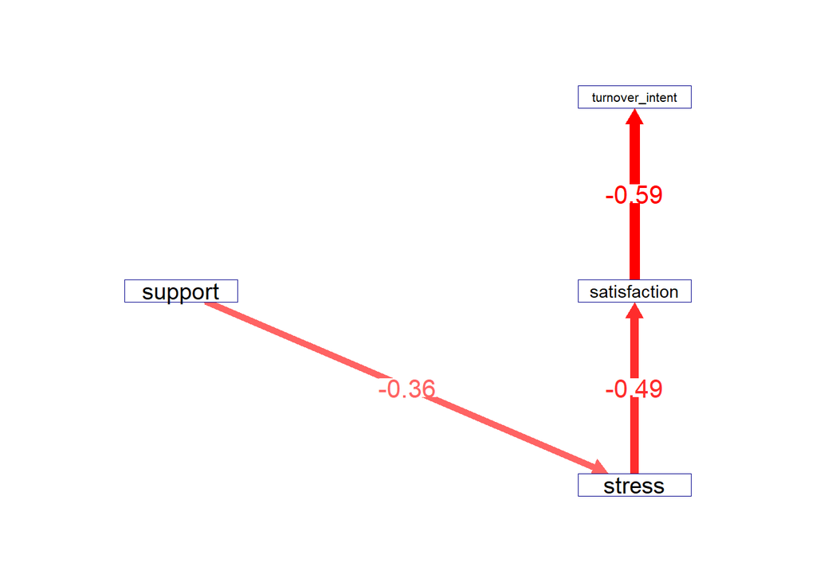

```r
semPaths( object = fit.2
         , what  = 'est, std'
         , style = 'lisrel'
         , curvePivot = TRUE
         , esize = 10
         , asize = 5    #arrowhead size
         , sizeMan2 = 3 #height of the manifest variables
         , nCharNodes = 0
         , edge.label.cex = 1.5
         , residuals = FALSE
         , sizeMan = 15
         , rotation = 2
         , theme = 'Borkulo')
```

```r
#note. The new comments are just arguments we didn´t use in the previous plot
```

Cool, notice how we rephrased the connection between support and stress to a onesided arrow. This can now be interprated as a regression weight, that is, for every unit increase in support we se a .36 unit decrease in stress. We also see a bigger coefficient for the relationship between stress and satisfaction. This is likley due to the fact that we presume that support does not inpact satisfaction but influences stress and thus, some of the variation we can explain in stress by support also influences satisfaction - i.e., stress mediates the relationship between support and satisfaction. The relationship between satisfaction and turnover intent is also different, but only by .01, that is, super small and an unimportant difference.

Now that we have two overidentified models we can compare the fit of them. This is surprisingly easy, we only use the anova function and our to model fits. Note that this is not a GLM anova but an LRT test, that is, a liklihood ratio test.

```r
anova(fit.1, fit.2)
```

```
## Scaled Chi-Squared Difference Test (method = "satorra.bentler.2001")
##
## lavaan NOTE:
##     The "Chisq" column contains standard test statistics, not the
##     robust test that should be reported per model. A robust difference
##     test is a function of two standard (not robust) statistics.
##
##       Df    AIC    BIC   Chisq Chisq diff Df diff Pr(>Chisq)
## fit.1  1 2858.5 2891.7  3.0141
## fit.2  3 2257.5 2279.6 11.8977     9.2498       2   0.009805 **
## ---
## Signif. codes:  0 '***' 0.001 '**' 0.01 '*' 0.05 '.' 0.1 ' ' 1
```

So what does this tell us? It tells us that the baseline model(fit.1) fits the data significantly better then the other model(fit.2). However, one should not that the AIC and BIC is lower for the fit.2 model, low scores on AIC and BIC is indicative of good fit, and models with lowe values are preferable to those with higher BIC and AIC. I do not feel particluarly stongly about any of these models, but if i had to choose one i would choose the second one since i like parsimony, but the first model technically fits better (though its almost identified so do with that what you will). For more on the LRT you can see: http://econ.upf.edu/~satorra/dades/BryantSatorraPaperInPressSEM.pdf

One last thing we can do before we move on to other things is the check the modification indicies. This is one cool thing that you can do with a path analysis that normal regression can´t really do. We will not use them for anything but it is interesting to look at them.

```r
modificationindices(fit.2) %>% arrange(-mi) %>% head(20)
```

```
##                lhs op             rhs    mi    epc sepc.lv sepc.all sepc.nox
## 1          support  ~    satisfaction 8.440  0.131   0.131    0.208    0.208
## 2     satisfaction  ~         support 8.440  0.252   0.252    0.158    0.235
## 3           stress ~~    satisfaction 8.440  0.299   0.299    0.468    0.468
## 4           stress  ~    satisfaction 8.440  0.341   0.341    0.500    0.500
## 5           stress  ~ turnover_intent 6.336 -0.109  -0.109   -0.184   -0.184
## 6          support  ~ turnover_intent 3.887 -0.067  -0.067   -0.124   -0.124
## 7           stress ~~ turnover_intent 3.408 -0.082  -0.082   -0.121   -0.121
## 8     satisfaction  ~ turnover_intent 2.351 -0.171  -0.171   -0.197   -0.197
## 9  turnover_intent  ~          stress 2.351 -0.139  -0.139   -0.083   -0.083
## 10    satisfaction ~~ turnover_intent 2.351 -0.170  -0.170   -0.182   -0.182
## 11 turnover_intent  ~         support 0.298 -0.048  -0.048   -0.026   -0.039
```

```r
#note. the %>% is a pipe function, they make code simpler to write so look in to them!
```

The modification indicies(mi column) shows how much the chi2 of the model would drop if the parameter was included. Thus, indicies over 3.84 will significantly increase the fit of the model. We have a few modifications we can make to our model, some of which improves the fit quite a bit.

Lastly, let´s do a sensitivity check by running the second model through the raw data. That is, the data with the outliers included.

```r
sensitivity.fit <- sem(  model = model.2
                       , data  = data
                       , estimator = 'MLM')

summary(sensitivity.fit, standardize  = TRUE, fit.measures = TRUE , rsquare = TRUE)
```

```
## lavaan 0.6-9 ended normally after 13 iterations
##
##   Estimator                                         ML
##   Optimization method                           NLMINB
##   Number of model parameters                         6
##
##   Number of observations                           322
##
## Model Test User Model:
##                                               Standard      Robust
##   Test Statistic                                10.159      10.615
##   Degrees of freedom                                 3           3
##   P-value (Chi-square)                           0.017       0.014
##   Scaling correction factor                                  0.957
##        Satorra-Bentler correction
##
## Model Test Baseline Model:
##
##   Test statistic                               267.940     254.344
##   Degrees of freedom                                 6           6
##   P-value                                        0.000       0.000
##   Scaling correction factor                                  1.053
##
## User Model versus Baseline Model:
##
##   Comparative Fit Index (CFI)                    0.973       0.969
##   Tucker-Lewis Index (TLI)                       0.945       0.939
##
##   Robust Comparative Fit Index (CFI)                         0.972
##   Robust Tucker-Lewis Index (TLI)                            0.944
##
## Loglikelihood and Information Criteria:
##
##   Loglikelihood user model (H0)              -1234.025   -1234.025
##   Loglikelihood unrestricted model (H1)      -1228.945   -1228.945
##
##   Akaike (AIC)                                2480.049    2480.049
##   Bayesian (BIC)                              2502.697    2502.697
##   Sample-size adjusted Bayesian (BIC)         2483.665    2483.665
##
```

[output cut: 26 more lines]

```
##     stress            -0.694    0.099   -7.007    0.000   -0.694   -0.482
##   turnover_intent ~
##     satisfaction      -0.672    0.048  -14.120    0.000   -0.672   -0.586
##
## Variances:
##                    Estimate  Std.Err  z-value  P(>|z|)   Std.lv  Std.all
##    .stress            0.493    0.060    8.155    0.000    0.493    0.891
##    .satisfaction      0.878    0.065   13.536    0.000    0.878    0.767
##    .turnover_intnt    0.989    0.074   13.405    0.000    0.989    0.657
##
## R-Square:
##                    Estimate
##     stress            0.109
##     satisfaction      0.233
##     turnover_intnt    0.343
```

```r
anova(sensitivity.fit, fit.2)
```

```
## Scaled Chi-Squared Difference Test (method = "satorra.bentler.2001")
##
## lavaan NOTE:
##     The "Chisq" column contains standard test statistics, not the
##     robust test that should be reported per model. A robust difference
##     test is a function of two standard (not robust) statistics.
##
##                 Df    AIC    BIC  Chisq Chisq diff Df diff Pr(>Chisq)
## sensitivity.fit  3 2480.1 2502.7 10.159
## fit.2            3 2257.5 2279.6 11.898     1.7384       0
```

```r
#note. We are comparing two models with the same degrees of freedom, this is not very appropriate since they are not nested(and on different data) but its nice to see the measures anyways.
```

So the model based on the raw data is not that different from we get when we have cleaned the data. This becomes even more apparent if we were to check the parameter estimates for the two models like so:

```r
parameterestimates(fit.2)
```

```
##               lhs op             rhs    est    se       z pvalue ci.lower
## 1          stress  ~         support -0.393 0.083  -4.756      0   -0.555
## 2    satisfaction  ~          stress -0.717 0.104  -6.920      0   -0.920
## 3 turnover_intent  ~    satisfaction -0.682 0.049 -13.783      0   -0.779
## 4          stress ~~          stress  0.466 0.057   8.237      0    0.355
## 5    satisfaction ~~    satisfaction  0.875 0.067  12.995      0    0.743
## 6 turnover_intent ~~ turnover_intent  0.996 0.074  13.531      0    0.851
## 7         support ~~         support  0.454 0.000      NA     NA    0.454
##   ci.upper
## 1   -0.231
## 2   -0.514
## 3   -0.585
## 4    0.577
## 5    1.007
## 6    1.140
## 7    0.454
```

```r
parameterestimates(sensitivity.fit)
```

```
##               lhs op             rhs    est    se       z pvalue ci.lower
## 1          stress  ~         support -0.346 0.073  -4.730      0   -0.489
## 2    satisfaction  ~          stress -0.694 0.099  -7.007      0   -0.888
## 3 turnover_intent  ~    satisfaction -0.672 0.048 -14.120      0   -0.765
## 4          stress ~~          stress  0.493 0.060   8.155      0    0.374
## 5    satisfaction ~~    satisfaction  0.878 0.065  13.536      0    0.751
## 6 turnover_intent ~~ turnover_intent  0.989 0.074  13.405      0    0.844
## 7         support ~~         support  0.504 0.000      NA     NA    0.504
##   ci.upper
## 1   -0.202
## 2   -0.500
## 3   -0.579
## 4    0.611
## 5    1.005
## 6    1.133
## 7    0.504
```

They are pretty much the same parameter estimates, certainly not significantly different. So what more can we do for this fun little analysis? we can do some bootstrapping. Lavaan has a really nice bootstrapping function that gives alot of freedom to choose what to do with the estimates. Let´s bootstrap all estimates from the second model(fit.2) and take a percentile intervall for them. Note that this can take a few seconds.

```r
boot_sample <- bootstrapLavaan( object = fit.2 #the fit we want to sample
                               , R     = 1000  #the number of iterations we want
)
```

Notice that “boot_sample” is a matrix of many estimates. Let´s put the regression coefficients in a dataframe and make our intervals.

```r
boot_sample <- data.frame(boot_sample)
boot_coef   <- select(boot_sample  #the data we want to take variables/cols from
                      , c(1,2,3,)) #a list of the cols we want to take(1,2,3)

quantile(boot_coef$stress.support     #the estimate we want to take intervals on
         , probs = c(.025, .5, .975)) #the percentile points we want to se
```

```
##       2.5%        50%      97.5%
## -0.5489199 -0.3825642 -0.2386760
```

```r
#we see that the regression weight ranges between -.55 and -.24

quantile(boot_coef$satisfaction.stress
         , probs = c(.025, .5, .975))
```

```
##       2.5%        50%      97.5%
## -0.9758261 -0.7247085 -0.5454487
```

```r
#we see that the regression weight ranges between -.98 and -.55

quantile(boot_coef$turnover_intent.satisfaction
         , probs = c(.025, .5, .975))
```

```
##       2.5%        50%      97.5%
## -0.7719642 -0.6811282 -0.5928512
```

```r
#we see that the regression weight ranges between -.77 and -.59
```

This is not super interesting, but it is pretty cool and also kind of illustrates what you can do with bootstrapping in a more manual way. There are of course much more you can do than to take percentile intervals of the regression weights but that lies beyond the specific realm of path analysis.